# NETFLIX CASE - STUDY

This Netflix Dataset has information about the TV Shows and Movies available on Nettlix til 2021

This dataset is collected from Flixable which is a third-party Netflix search engine, and available on Kaggle website for free.

```python
import pandas as pd
```

```python
df = pd.read_csv("8. Netflix Dataset.csv")
```

```python
df.head() #It shows the first N rows in the data (by default, N=5).
```

|  | Show_Id | Category | Title | Director | Cast | Country | Release_Date | Rating | Duration | Type | Description |
| --- | --- | --- | --- | --- | --- | --- | --- | --- | --- | --- | --- |
| 0 | s1 | TV Show | 3% | NaN | João Miguel, Bianca Comparato, Michel Gomes, R... | Brazil | August 14, 2020 | TV-MA | 4 Seasons | International TV Shows, TV Dramas, TV Sci-Fi &... | In a future where the elite inhabit an island ... |
| 1 | s2 | Movie | 07:19 | Jorge Michel Grau | Demián Bichir, Héctor Bonilla, Oscar Serrano, ... | Mexico | December 23, 2016 | TV-MA | 93 min | Dramas, International Movies | After a devastating earthquake hits Mexico Cit... |
| 2 | s3 | Movie | 23:59 | Gilbert Chan | Tedd Chan, Stella Chung, Henley Hii, Lawrence ... | Singapore | December 20, 2018 | R | 78 min | Horror Movies, International Movies | When an army recruit is found dead, his fellow... |
| 3 | s4 | Movie | 9 | Shane Acker | Elijah Wood, John C. Reilly, Jennifer Connelly... | United States | November 16, 2017 | PG-13 | 80 min | Action & Adventure, Independent Movies, Sci-Fi... | In a postapocalyptic world, rag-doll robots hi... |
| 4 | s5 | Movie | 21 | Robert Luketic | Jim Sturgess, Kevin Spacey, Kate Bosworth, Aar... | United States | January 1, 2020 | PG-13 | 123 min | Dramas | A brilliant group of students become card-coun... |

```python
df.tail() #It shows the last N rows in the data (by default, N=5).
```

|  | Show_Id | Category | Title | Director | Cast | Country | Release_Date | Rating | Duration | Type | Description |
| --- | --- | --- | --- | --- | --- | --- | --- | --- | --- | --- | --- |
| 7784 | s7783 | Movie | Zozo | Josef Fares | Imad Creidi, Antoinette Turk, Elias Gergi, Car... | Sweden, Czech Republic, United Kingdom, Denmar... | October 19, 2020 | TV-MA | 99 min | Dramas, International Movies | When Lebanon's Civil War deprives Zozo of his ... |
| 7785 | s7784 | Movie | Zubaan | Mozez Singh | Vicky Kaushal, Sarah-Jane Dias, Raaghav Chanan... | India | March 2, 2019 | TV-14 | 111 min | Dramas, International Movies, Music & Musicals | A scrappy but poor boy worms his way into a ty... |
| 7786 | s7785 | Movie | Zulu Man in Japan | NaN | Nasty C | NaN | September 25, 2020 | TV-MA | 44 min | Documentaries, International Movies, Music & M... | In this documentary, South African rapper Nast... |
| 7787 | s7786 | TV Show | Zumbo's Just Desserts | NaN | Adriano Zumbo, Rachel Khoo | Australia | October 31, 2020 | TV-PG | 1 Season | International TV Shows, Reality TV | Dessert wizard Adriano Zumbo looks for the nex... |
| 7788 | s7787 | Movie | ZZ TOP: THAT LITTLE OL' BAND FROM TEXAS | Sam Dunn | NaN | United Kingdom, Canada, United States | March 1, 2020 | TV-MA | 90 min | Documentaries, Music & Musicals | This documentary delves into the mystique behi... |

```python
df.shape # It shows the total no. of rows and no. of columns of the dataframe.
```

```
(7789, 11)
```

```python
df.size #To show No. of total values(elements) in the dataset.
```

```
85679
```

```python
df.columns #To show each Column Name.
```

```
Index(['Show_Id', 'Category', 'Title', 'Director', 'Cast', 'Country',
       'Release_Date', 'Rating', 'Duration', 'Type', 'Description'],
      dtype='object')
```

```python
df.dtypes #To show the data-type of each column.
```

```
Show_Id         object
Category        object
Title           object
Director        object
Cast            object
Country         object
Release_Date    object
Rating          object
Duration        object
Type            object
Description     object
dtype: object
```

```python
df.info() #To show indexes, columns, data-types of each column, memory at once.
```

```
<class 'pandas.core.frame.DataFrame'>
RangeIndex: 7789 entries, 0 to 7788
Data columns (total 11 columns):
 #   Column        Non-Null Count  Dtype
---  ------        --------------  -----
 0   Show_Id       7789 non-null   object
 1   Category      7789 non-null   object
 2   Title         7789 non-null   object
 3   Director      5401 non-null   object
 4   Cast          7071 non-null   object
 5   Country       7282 non-null   object
 6   Release_Date  7779 non-null   object
 7   Rating        7782 non-null   object
 8   Duration      7789 non-null   object
 9   Type          7789 non-null   object
 10  Description   7789 non-null   object
dtypes: object(11)
memory usage: 669.5+ KB
```

Task. 1) Is there any Duplicate Record in this dataset ? If yes, then remove the duplicate records.

```python
df[df.duplicated()] #duplicated( ) - To check row wise and detect the Duplicate rows.
```

|  | Show_Id | Category | Title | Director | Cast | Country | Release_Date | Rating | Duration | Type | Description |
| --- | --- | --- | --- | --- | --- | --- | --- | --- | --- | --- | --- |
| 6300 | s684 | Movie | Backfire | Dave Patten | Black Deniro, Byron "Squally" Vinson, Dominic ... | United States | April 5, 2019 | TV-MA | 97 min | Dramas, Independent Movies, Thrillers | When two would-be robbers accidentally kill a ... |
| 6622 | s6621 | Movie | The Lost Okoroshi | Abba T. Makama | Seun Ajayi, Judith Audu, Tope Tedela, Ifu Enna... | Nigeria | September 4, 2020 | TV-MA | 94 min | Comedies, Dramas, Independent Movies | A disillusioned security guard transforms into... |

```python
df.drop_duplicates(inplace = True) # dropping duplicated rows
```

```python
df[df.duplicated()]
```

|  | Show_Id | Category | Title | Director | Cast | Country | Release_Date | Rating | Duration | Type | Description |
| --- | --- | --- | --- | --- | --- | --- | --- | --- | --- | --- | --- |

Task. 2) Is there any Null Value present in any column ? Show with Heat-map.

```python
df.isnull().sum() # isnull( ) - To show where Null value is present.
```

```
Show_Id            0
Category           0
Title              0
Director        2388
Cast             718
Country          507
Release_Date      10
Rating             7
Duration           0
Type               0
Description        0
dtype: int64
```

seaborn library for heatmap

```python
import seaborn as sns
```

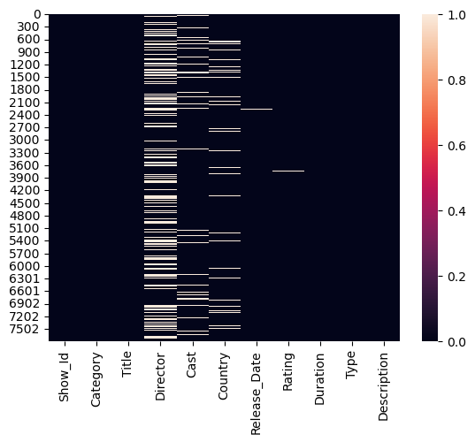

```python
sns.heatmap(df.isnull())
```

Q. 1) For 'House of Cards', what is the Show Id and Who is the Director of this show ?

```python
df.head()
```

|  | Show_Id | Category | Title | Director | Cast | Country | Release_Date | Rating | Duration | Type | Description |
| --- | --- | --- | --- | --- | --- | --- | --- | --- | --- | --- | --- |
| 0 | s1 | TV Show | 3% | NaN | João Miguel, Bianca Comparato, Michel Gomes, R... | Brazil | August 14, 2020 | TV-MA | 4 Seasons | International TV Shows, TV Dramas, TV Sci-Fi &... | In a future where the elite inhabit an island ... |
| 1 | s2 | Movie | 07:19 | Jorge Michel Grau | Demián Bichir, Héctor Bonilla, Oscar Serrano, ... | Mexico | December 23, 2016 | TV-MA | 93 min | Dramas, International Movies | After a devastating earthquake hits Mexico Cit... |
| 2 | s3 | Movie | 23:59 | Gilbert Chan | Tedd Chan, Stella Chung, Henley Hii, Lawrence ... | Singapore | December 20, 2018 | R | 78 min | Horror Movies, International Movies | When an army recruit is found dead, his fellow... |
| 3 | s4 | Movie | 9 | Shane Acker | Elijah Wood, John C. Reilly, Jennifer Connelly... | United States | November 16, 2017 | PG-13 | 80 min | Action & Adventure, Independent Movies, Sci-Fi... | In a postapocalyptic world, rag-doll robots hi... |
| 4 | s5 | Movie | 21 | Robert Luketic | Jim Sturgess, Kevin Spacey, Kate Bosworth, Aar... | United States | January 1, 2020 | PG-13 | 123 min | Dramas | A brilliant group of students become card-coun... |

```python
df[df["Title"].isin(["House of Cards"])] #To show all records including particular elements.
```

|  | Show_Id | Category | Title | Director | Cast | Country | Release_Date | Rating | Duration | Type | Description |
| --- | --- | --- | --- | --- | --- | --- | --- | --- | --- | --- | --- |
| 2832 | s2833 | TV Show | House of Cards | Robin Wright, David Fincher, Gerald McRaney, J... | Kevin Spacey, Robin Wright, Kate Mara, Corey S... | United States | November 2, 2018 | TV-MA | 6 Seasons | TV Dramas, TV Thrillers | A ruthless politician will stop at nothing to ... |

```python
df[df["Title"].str.contains("House of Cards")] # To get all records that contains a given string.
```

|  | Show_Id | Category | Title | Director | Cast | Country | Release_Date | Rating | Duration | Type | Description |
| --- | --- | --- | --- | --- | --- | --- | --- | --- | --- | --- | --- |
| 2832 | s2833 | TV Show | House of Cards | Robin Wright, David Fincher, Gerald McRaney, J... | Kevin Spacey, Robin Wright, Kate Mara, Corey S... | United States | November 2, 2018 | TV-MA | 6 Seasons | TV Dramas, TV Thrillers | A ruthless politician will stop at nothing to ... |

Q. 2) In which year the highest number of the TV Shows & Movies were released ? Show with Bar Graph.

```python
df.info()
```

```
<class 'pandas.core.frame.DataFrame'>
RangeIndex: 7789 entries, 0 to 7788
Data columns (total 11 columns):
 #   Column        Non-Null Count  Dtype
---  ------        --------------  -----
 0   Show_Id       7789 non-null   object
 1   Category      7789 non-null   object
 2   Title         7789 non-null   object
 3   Director      5401 non-null   object
 4   Cast          7071 non-null   object
 5   Country       7282 non-null   object
 6   Release_Date  7779 non-null   object
 7   Rating        7782 non-null   object
 8   Duration      7789 non-null   object
 9   Type          7789 non-null   object
 10  Description   7789 non-null   object
dtypes: object(11)
memory usage: 669.5+ KB
```

```python
df["Release_Date"] = pd.to_datetime(df["Release_Date"]) #Converts the data-type of Date-Time Column into datetime[ns] datatype.
```

```python
df.dtypes
```

```
Show_Id                 object
Category                object
Title                   object
Director                object
Cast                    object
Country                 object
Release_Date    datetime64[ns]
Rating                  object
Duration                object
Type                    object
Description             object
dtype: object
```

```python
df["Release_Date"].dt.year.value_counts() #dt.year.value_counts( ) - It counts the occurrence of all individual years in Time column.
```

```
2019.0    2154
2020.0    2010
2018.0    1685
2017.0    1225
2016.0     443
2021.0     117
2015.0      88
2014.0      25
2011.0      13
2013.0      11
2012.0       3
2008.0       2
2009.0       2
2010.0       1
Name: Release_Date, dtype: int64
```

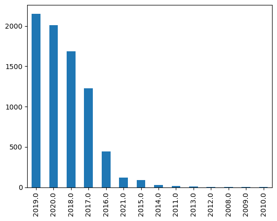

```python
df["Release_Date"].dt.year.value_counts().plot(kind = "bar")
```

Q. 3) How many Movies & TV Shows are in the dataset ? Show with Bar Graph.

```python
df.head()
```

|  | Show_Id | Category | Title | Director | Cast | Country | Release_Date | Rating | Duration | Type | Description |
| --- | --- | --- | --- | --- | --- | --- | --- | --- | --- | --- | --- |
| 0 | s1 | TV Show | 3% | NaN | João Miguel, Bianca Comparato, Michel Gomes, R... | Brazil | 2020-08-14 | TV-MA | 4 Seasons | International TV Shows, TV Dramas, TV Sci-Fi &... | In a future where the elite inhabit an island ... |
| 1 | s2 | Movie | 07:19 | Jorge Michel Grau | Demián Bichir, Héctor Bonilla, Oscar Serrano, ... | Mexico | 2016-12-23 | TV-MA | 93 min | Dramas, International Movies | After a devastating earthquake hits Mexico Cit... |
| 2 | s3 | Movie | 23:59 | Gilbert Chan | Tedd Chan, Stella Chung, Henley Hii, Lawrence ... | Singapore | 2018-12-20 | R | 78 min | Horror Movies, International Movies | When an army recruit is found dead, his fellow... |
| 3 | s4 | Movie | 9 | Shane Acker | Elijah Wood, John C. Reilly, Jennifer Connelly... | United States | 2017-11-16 | PG-13 | 80 min | Action & Adventure, Independent Movies, Sci-Fi... | In a postapocalyptic world, rag-doll robots hi... |
| 4 | s5 | Movie | 21 | Robert Luketic | Jim Sturgess, Kevin Spacey, Kate Bosworth, Aar... | United States | 2020-01-01 | PG-13 | 123 min | Dramas | A brilliant group of students become card-coun... |

```python
df.groupby("Category").Category.count()
```

```
Category
Movie      5379
TV Show    2410
Name: Category, dtype: int64
```

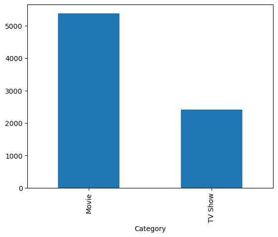

```python
df.groupby("Category").Category.count().plot(kind = "bar")
```

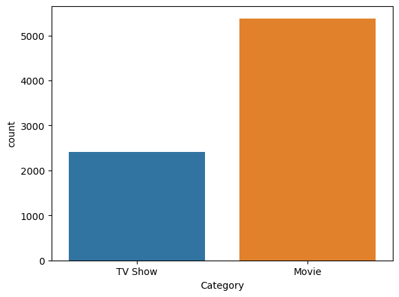

```python
sns.countplot(df["Category"]) # sns.countplot(df['Col_name']) - To show the count of all unique values of any column in the form of bar graph.
```

Q. 4) Show all the Movies that were released in year 2000.

```python
df.head()
```

|  | Show_Id | Category | Title | Director | Cast | Country | Release_Date | Rating | Duration | Type | Description |
| --- | --- | --- | --- | --- | --- | --- | --- | --- | --- | --- | --- |
| 0 | s1 | TV Show | 3% | NaN | João Miguel, Bianca Comparato, Michel Gomes, R... | Brazil | 2020-08-14 | TV-MA | 4 Seasons | International TV Shows, TV Dramas, TV Sci-Fi &... | In a future where the elite inhabit an island ... |
| 1 | s2 | Movie | 07:19 | Jorge Michel Grau | Demián Bichir, Héctor Bonilla, Oscar Serrano, ... | Mexico | 2016-12-23 | TV-MA | 93 min | Dramas, International Movies | After a devastating earthquake hits Mexico Cit... |
| 2 | s3 | Movie | 23:59 | Gilbert Chan | Tedd Chan, Stella Chung, Henley Hii, Lawrence ... | Singapore | 2018-12-20 | R | 78 min | Horror Movies, International Movies | When an army recruit is found dead, his fellow... |
| 3 | s4 | Movie | 9 | Shane Acker | Elijah Wood, John C. Reilly, Jennifer Connelly... | United States | 2017-11-16 | PG-13 | 80 min | Action & Adventure, Independent Movies, Sci-Fi... | In a postapocalyptic world, rag-doll robots hi... |
| 4 | s5 | Movie | 21 | Robert Luketic | Jim Sturgess, Kevin Spacey, Kate Bosworth, Aar... | United States | 2020-01-01 | PG-13 | 123 min | Dramas | A brilliant group of students become card-coun... |

```python
df[(df["Release_Date"].dt.year ==2000) & (df["Category"] == "Movie")]
```

|  | Show_Id | Category | Title | Director | Cast | Country | Release_Date | Rating | Duration | Type | Description |
| --- | --- | --- | --- | --- | --- | --- | --- | --- | --- | --- | --- |

Q. 5) Show only the Titles of all TV Shows that were released in India only.

```python
df1 = df[(df["Country"] =="India") & (df["Category"] == "TV Show")]
```

```python
df1["Title"]
```

```
86            21 Sarfarosh: Saragarhi 1897
132                              7 (Seven)
340                           Agent Raghav
364                           Akbar Birbal
533                    Anjaan: Rural Myths
                       ...
6249                  The Creative Indians
6400    The Golden Years with Javed Akhtar
6469                The House That Made Me
7294                            Typewriter
7705                       Yeh Meri Family
Name: Title, Length: 71, dtype: object
```

Q. 6) Show Top 10 Directors, who gave the highest number of TV Shows & Movies to Netflix ?

```python
df.groupby("Director").Category.count().sort_values(ascending = False).head(10)
```

```
Director
Raúl Campos, Jan Suter    18
Marcus Raboy              16
Jay Karas                 14
Cathy Garcia-Molina       13
Martin Scorsese           12
Jay Chapman               12
Youssef Chahine           12
Steven Spielberg          10
David Dhawan               9
Robert Rodriguez           8
Name: Category, dtype: int64
```

Q. 7) Show all the Records, where "Category is Movie and Type is Comedies" or "Country is United Kingdom".

```python
df.head()
```

|  | Show_Id | Category | Title | Director | Cast | Country | Release_Date | Rating | Duration | Type | Description |
| --- | --- | --- | --- | --- | --- | --- | --- | --- | --- | --- | --- |
| 0 | s1 | TV Show | 3% | NaN | João Miguel, Bianca Comparato, Michel Gomes, R... | Brazil | 2020-08-14 | TV-MA | 4 Seasons | International TV Shows, TV Dramas, TV Sci-Fi &... | In a future where the elite inhabit an island ... |
| 1 | s2 | Movie | 07:19 | Jorge Michel Grau | Demián Bichir, Héctor Bonilla, Oscar Serrano, ... | Mexico | 2016-12-23 | TV-MA | 93 min | Dramas, International Movies | After a devastating earthquake hits Mexico Cit... |
| 2 | s3 | Movie | 23:59 | Gilbert Chan | Tedd Chan, Stella Chung, Henley Hii, Lawrence ... | Singapore | 2018-12-20 | R | 78 min | Horror Movies, International Movies | When an army recruit is found dead, his fellow... |
| 3 | s4 | Movie | 9 | Shane Acker | Elijah Wood, John C. Reilly, Jennifer Connelly... | United States | 2017-11-16 | PG-13 | 80 min | Action & Adventure, Independent Movies, Sci-Fi... | In a postapocalyptic world, rag-doll robots hi... |
| 4 | s5 | Movie | 21 | Robert Luketic | Jim Sturgess, Kevin Spacey, Kate Bosworth, Aar... | United States | 2020-01-01 | PG-13 | 123 min | Dramas | A brilliant group of students become card-coun... |

```python
df[(df["Category"] =="Movie") & (df["Type"]=="Comedies")| (df["Country"]=="United Kingdom")]
```

|  | Show_Id | Category | Title | Director | Cast | Country | Release_Date | Rating | Duration | Type | Description |
| --- | --- | --- | --- | --- | --- | --- | --- | --- | --- | --- | --- |
| 19 | s20 | Movie | '89 | NaN | Lee Dixon, Ian Wright, Paul Merson | United Kingdom | 2018-05-16 | TV-PG | 87 min | Sports Movies | Mixing old footage with interviews, this is th... |
| 33 | s34 | Movie | #realityhigh | Fernando Lebrija | Nesta Cooper, Kate Walsh, John Michael Higgins... | United States | 2017-09-08 | TV-14 | 99 min | Comedies | When nerdy high schooler Dani finally attracts... |
| 58 | s59 | TV Show | 100% Hotter | NaN | Daniel Palmer, Melissa Sophia, Karen Williams,... | United Kingdom | 2019-11-01 | TV-14 | 1 Season | British TV Shows, International TV Shows, Real... | A stylist, a hair designer and a makeup artist... |
| 72 | s73 | Movie | 17 Again | Burr Steers | Zac Efron, Leslie Mann, Matthew Perry, Thomas ... | United States | 2021-01-01 | PG-13 | 102 min | Comedies | Nearing a midlife crisis, thirty-something Mik... |
| 82 | s83 | Movie | 2036 Origin Unknown | Hasraf Dulull | Katee Sackhoff, Ray Fearon, Julie Cox, Steven ... | United Kingdom | 2018-12-20 | TV-14 | 95 min | Sci-Fi & Fantasy | Working with an artificial intelligence to inv... |
| ... | ... | ... | ... | ... | ... | ... | ... | ... | ... | ... | ... |
| 7670 | s7669 | TV Show | World War II in Colour | NaN | Robert Powell | United Kingdom | 2017-08-01 | TV-MA | 1 Season | British TV Shows, Docuseries, International TV... | Footage of the most dramatic moments from Worl... |
| 7671 | s7670 | TV Show | World's Busiest Cities | NaN | Anita Rani, Ade Adepitan, Dan Snow | United Kingdom | 2019-02-01 | TV-PG | 1 Season | British TV Shows, Docuseries | From Moscow to Mexico City, three BBC journali... |
| 7688 | s7687 | Movie | XV: Beyond the Tryline | Pierre Deschamps | NaN | United Kingdom | 2020-03-18 | TV-14 | 91 min | Documentaries, Sports Movies | Set against the 2015 Rugby World Cup, this doc... |
| 7725 | s7724 | Movie | You Can Tutu | James Brown | Lily O'Regan, Jeannettsy Enriquez Borges, Joel... | United Kingdom | 2017-12-31 | TV-G | 87 min | Children & Family Movies | A gifted young ballet dancer struggles to find... |
| 7740 | s7739 | TV Show | Young Wallander | NaN | Adam Pålsson, Richard Dillane, Leanne Best, El... | United Kingdom | 2020-09-03 | TV-MA | 1 Season | Crime TV Shows, International TV Shows, TV Dramas | An incendiary hate crime stirs civil unrest, f... |

485 rows × 11 columns

Q. 8) In how many movies/shows, Tom Cruise was cast ?

```python
df[df["Cast"] =="Tom Cruise"]
```

|  | Show_Id | Category | Title | Director | Cast | Country | Release_Date | Rating | Duration | Type | Description |
| --- | --- | --- | --- | --- | --- | --- | --- | --- | --- | --- | --- |

```python
df1 = df.dropna()
df1
df1[df1["Cast"].str.contains("Tom Cruise")]
```

|  | Show_Id | Category | Title | Director | Cast | Country | Release_Date | Rating | Duration | Type | Description |
| --- | --- | --- | --- | --- | --- | --- | --- | --- | --- | --- | --- |
| 3860 | s3861 | Movie | Magnolia | Paul Thomas Anderson | Jeremy Blackman, Tom Cruise, Melinda Dillon, A... | United States | 2020-01-01 | R | 189 min | Dramas, Independent Movies | Through chance, human action, past history and... |
| 5071 | s5071 | Movie | Rain Man | Barry Levinson | Dustin Hoffman, Tom Cruise, Valeria Golino, Ge... | United States | 2019-07-01 | R | 134 min | Classic Movies, Dramas | A fast-talking yuppie is forced to slow down w... |

Q. 9) What are the different Ratings defined by Netflix ?

```python
df["Rating"].nunique()
```

```
14
```

```python
df["Rating"].unique()
```

```
array(['TV-MA', 'R', 'PG-13', 'TV-14', 'TV-PG', 'NR', 'TV-G', 'TV-Y', nan,
       'TV-Y7', 'PG', 'G', 'NC-17', 'TV-Y7-FV', 'UR'], dtype=object)
```

Q. 9.1) How many Movies got the 'TV-14' rating, in Canada ?

```python
len(df[(df["Rating"] == "TV-14") & (df["Country"] == "Canada") & (df["Category"] =="Movie")])
```

```
11
```

Q. 9.2) How many TV Shows got the 'R' rating, after year 2018 ?

```python
df[(df["Category"] =="TV Show") & (df["Rating"] =="R") & (df["Release_Date"].dt.year > 2018)]
```

|  | Show_Id | Category | Title | Director | Cast | Country | Release_Date | Rating | Duration | Type | Description |
| --- | --- | --- | --- | --- | --- | --- | --- | --- | --- | --- | --- |
| 6437 | s6436 | TV Show | The Hateful Eight: Extended Version | Quentin Tarantino | Samuel L. Jackson, Kurt Russell, Jennifer Jaso... | NaN | 2019-04-25 | R | 1 Season | TV Shows | Trapped at a stagecoach stop as a storm rages ... |

Q. 10) What is the maximum duration of a Movie/Show on Netflix ?

```python
df["Duration"].max()
```

```
'99 min'
```

```python
df[["min","unit"]] = df["Duration"].str.split(" ",expand = True)
```

```python
df
```

|  | Show_Id | Category | Title | Director | Cast | Country | Release_Date | Rating | Duration | Type | Description | min | unit |
| --- | --- | --- | --- | --- | --- | --- | --- | --- | --- | --- | --- | --- | --- |
| 0 | s1 | TV Show | 3% | NaN | João Miguel, Bianca Comparato, Michel Gomes, R... | Brazil | 2020-08-14 | TV-MA | 4 Seasons | International TV Shows, TV Dramas, TV Sci-Fi &... | In a future where the elite inhabit an island ... | 4 | Seasons |
| 1 | s2 | Movie | 07:19 | Jorge Michel Grau | Demián Bichir, Héctor Bonilla, Oscar Serrano, ... | Mexico | 2016-12-23 | TV-MA | 93 min | Dramas, International Movies | After a devastating earthquake hits Mexico Cit... | 93 | min |
| 2 | s3 | Movie | 23:59 | Gilbert Chan | Tedd Chan, Stella Chung, Henley Hii, Lawrence ... | Singapore | 2018-12-20 | R | 78 min | Horror Movies, International Movies | When an army recruit is found dead, his fellow... | 78 | min |
| 3 | s4 | Movie | 9 | Shane Acker | Elijah Wood, John C. Reilly, Jennifer Connelly... | United States | 2017-11-16 | PG-13 | 80 min | Action & Adventure, Independent Movies, Sci-Fi... | In a postapocalyptic world, rag-doll robots hi... | 80 | min |
| 4 | s5 | Movie | 21 | Robert Luketic | Jim Sturgess, Kevin Spacey, Kate Bosworth, Aar... | United States | 2020-01-01 | PG-13 | 123 min | Dramas | A brilliant group of students become card-coun... | 123 | min |
| ... | ... | ... | ... | ... | ... | ... | ... | ... | ... | ... | ... | ... | ... |
| 7784 | s7783 | Movie | Zozo | Josef Fares | Imad Creidi, Antoinette Turk, Elias Gergi, Car... | Sweden, Czech Republic, United Kingdom, Denmar... | 2020-10-19 | TV-MA | 99 min | Dramas, International Movies | When Lebanon's Civil War deprives Zozo of his ... | 99 | min |
| 7785 | s7784 | Movie | Zubaan | Mozez Singh | Vicky Kaushal, Sarah-Jane Dias, Raaghav Chanan... | India | 2019-03-02 | TV-14 | 111 min | Dramas, International Movies, Music & Musicals | A scrappy but poor boy worms his way into a ty... | 111 | min |
| 7786 | s7785 | Movie | Zulu Man in Japan | NaN | Nasty C | NaN | 2020-09-25 | TV-MA | 44 min | Documentaries, International Movies, Music & M... | In this documentary, South African rapper Nast... | 44 | min |
| 7787 | s7786 | TV Show | Zumbo's Just Desserts | NaN | Adriano Zumbo, Rachel Khoo | Australia | 2020-10-31 | TV-PG | 1 Season | International TV Shows, Reality TV | Dessert wizard Adriano Zumbo looks for the nex... | 1 | Season |
| 7788 | s7787 | Movie | ZZ TOP: THAT LITTLE OL' BAND FROM TEXAS | Sam Dunn | NaN | United Kingdom, Canada, United States | 2020-03-01 | TV-MA | 90 min | Documentaries, Music & Musicals | This documentary delves into the mystique behi... | 90 | min |

7789 rows × 13 columns

```python
df["Duration"].max()
```

```
'99 min'
```

Q. 11) Which individual country has the Highest No. of TV Shows ?

```python
df1 =df[df["Category"]=="TV Show"]
df1
```

|  | Show_Id | Category | Title | Director | Cast | Country | Release_Date | Rating | Duration | Type | Description | min | unit |
| --- | --- | --- | --- | --- | --- | --- | --- | --- | --- | --- | --- | --- | --- |
| 0 | s1 | TV Show | 3% | NaN | João Miguel, Bianca Comparato, Michel Gomes, R... | Brazil | 2020-08-14 | TV-MA | 4 Seasons | International TV Shows, TV Dramas, TV Sci-Fi &... | In a future where the elite inhabit an island ... | 4 | Seasons |
| 5 | s6 | TV Show | 46 | Serdar Akar | Erdal Beşikçioğlu, Yasemin Allen, Melis Birkan... | Turkey | 2017-07-01 | TV-MA | 1 Season | International TV Shows, TV Dramas, TV Mysteries | A genetics professor experiments with a treatm... | 1 | Season |
| 11 | s12 | TV Show | 1983 | NaN | Robert Więckiewicz, Maciej Musiał, Michalina O... | Poland, United States | 2018-11-30 | TV-MA | 1 Season | Crime TV Shows, International TV Shows, TV Dramas | In this dark alt-history thriller, a naïve law... | 1 | Season |
| 12 | s13 | TV Show | 1994 | Diego Enrique Osorno | NaN | Mexico | 2019-05-17 | TV-MA | 1 Season | Crime TV Shows, Docuseries, International TV S... | Archival video and new interviews examine Mexi... | 1 | Season |
| 16 | s17 | TV Show | Feb-09 | NaN | Shahd El Yaseen, Shaila Sabt, Hala, Hanadi Al-... | NaN | 2019-03-20 | TV-14 | 1 Season | International TV Shows, TV Dramas | As a psychology professor faces Alzheimer's, h... | 1 | Season |
| ... | ... | ... | ... | ... | ... | ... | ... | ... | ... | ... | ... | ... | ... |
| 7769 | s7768 | TV Show | Zindagi Gulzar Hai | NaN | Sanam Saeed, Fawad Khan, Ayesha Omer, Mehreen ... | Pakistan | 2016-12-15 | TV-PG | 1 Season | International TV Shows, Romantic TV Shows, TV ... | Strong-willed, middle-class Kashaf and carefre... | 1 | Season |
| 7777 | s7776 | TV Show | Zoids Wild | NaN | Kensho Ono, Takahiro Sakurai, Mikako Komatsu, ... | Japan | 2020-08-14 | TV-Y7 | 1 Season | Anime Series, Kids' TV | A quest for freedom and legendary treasure beg... | 1 | Season |
| 7779 | s7778 | TV Show | Zombie Dumb | NaN | NaN | NaN | 2019-07-01 | TV-Y7 | 2 Seasons | Kids' TV, Korean TV Shows, TV Comedies | While living alone in a spooky town, a young g... | 2 | Seasons |
| 7781 | s7780 | TV Show | Zona Rosa | NaN | Manu NNa, Ana Julia Yeyé, Ray Contreras, Pablo... | Mexico | 2019-11-26 | TV-MA | 1 Season | International TV Shows, Spanish-Language TV Sh... | An assortment of talent takes the stage for a ... | 1 | Season |
| 7787 | s7786 | TV Show | Zumbo's Just Desserts | NaN | Adriano Zumbo, Rachel Khoo | Australia | 2020-10-31 | TV-PG | 1 Season | International TV Shows, Reality TV | Dessert wizard Adriano Zumbo looks for the nex... | 1 | Season |

2410 rows × 13 columns

```python
df1.groupby("Country").Category.count().sort_values(ascending = False).head(5)
```

```
Country
United States     705
United Kingdom    204
Japan             157
South Korea       147
India              71
Name: Category, dtype: int64
```